# 01. Introduction

Chris Bailiss

2019-11-01

## In This Vignette

- Introducing pivottabler
- Pivot Tables
  - Quick Example
  - Definition
  - In reality
- Sample Data
- Basic Pivot Table
- Constructing the Basic Pivot Table
- Outputting the Pivot Table as Plain Text
- Extending the Basic Pivot Table
- Quick-Pivot Functions
- Examples Gallery
- Further Reading

## Introducing pivottabler

The `pivottabler` package enables pivot tables to be created and rendered/exported with just a few lines of R.

Pivot tables are constructed natively in R, either via a short one line command to build a basic pivot table or via series of R commands that gradually build a more bespoke pivot table to meet your needs.

The `pivottabler` package:

- provides a simple framework for specifying and aggregating data, based on either the dplyr package or the data.table package.
- provides optional hooks for specifying custom calculations/aggregations for more complex scenarios
  - This allows a wide-range of R functions, including custom functions written in R, to be used in the calculation logic.
- does not require the user to specify low-level layout logic.
- supports output in multiple formats as well as converting a pivot table to either a standard R matrix or data frame.

Since pivot tables are primarily visualisation tools, the pivottabler package offers several custom styling options as well as conditional/custom formatting capabilities so that the pivot tables can be themed/branded as needed.

Output can be rendered as:

- HTML, including via the htmlwidgets framework,
- Latex, e.g. to PDF, or
- Plain text, e.g. to the console.

The generated HTML, Latex and text can also be easily retrieved, e.g. to be used outside of R

The pivot tables can also be exported to Excel, including the styling/formatting.

`pivottabler` is a companion package to the `basictabler` package. `pivottabler` is focussed on generating pivot tables and can aggregate data. `basictabler` does not aggregate data but offers more control of table structure.

The latest version of the pivottabler package can be obtained directly from the [package repository](https://github.com/cbailiss/pivottabler/). Please log any questions not answered by the vignettes or any bug reports [here](https://github.com/cbailiss/pivottabler/issues).

## Pivot Tables

### Quick Example

An example of a pivot table showing the number of trains operated by different train companies is:

```r
library(pivottabler)
# arguments:  qhpvt(dataFrame, rows, columns, calculations, ...)
qhpvt(bhmtrains, "TOC", "TrainCategory", "n()") # TOC = Train Operating Company
```

[interactive chart not shown]

This example pivot table is explained in more detail later in this vignette.

Examples of pivot tables containing other types of calculation can be found in the examples gallery later in the vignette.

### Definition

Pivot tables are a common technique for summarising large tables of data into smaller and more easily understood summary tables to answer specific questions.

Starting from a specific question that requires answering, the variables relevant to the question are identified. The distinct values of the fixed variables[^1] are rendered as a mixture of row and column headings in the summary table. One or more aggregations of the (numerical) measured variables are added into the body of the table, where the row/column headings act as data groups. The summary table should then yield an answer to the original question.

### In reality

The definition above is probably more difficult to understand than just looking at some examples - several are presented in this vignette. An extended definition is also provided by [Wikipedia](https://en.wikipedia.org/wiki/Pivot_table).

Pivot tables can be found in everyday use within many commercial and non-commercial organisations. Pivot tables feature prominently in applications such as Microsoft Excel, Open Office, etc. More advanced forms are found in Business Intelligence (BI) and Online Analytical Processing (OLAP) tools.

## Sample Data: Trains in Birmingham

To build a series of example pivot tables, we will use the `bhmtrains` data frame. This contains all 83,710 trains that arrived into and/or departed from [Birmingham New Street railway station](https://en.wikipedia.org/wiki/Birmingham_New_Street_station) between 1st December 2016 and 28th February 2017. As an example, the following are four trains that arrived into Birmingham New Street at the very start of this time period - note the data has been transposed (otherwise the table would be very wide).

[interactive chart not shown]

GbttArrival and GbttDeparture are the scheduled arrival and departure times of the trains at Birmingham New Street, as advertised in the Great Britain Train Timetable (GBTT). Also given are the actual arrival and departure times of the trains at Birmingham New Street. Note that all four of the trains above terminated at New Street, hence they have arrival times but no departure times. The origin and destination stations of each of the trains is also included, in the form of three letter station codes, e.g. BHM = Birmingham New Street. The `trainstations` data frame (used later in this vignette) includes a lookup from the code to the full station name for all stations.

The first train above:

- has an identifier of 33960725[^2].
- was operated by the London Midland train operating company.
- was an express passenger train (=fewer stops).
- was scheduled to be operated by an “Electric Multiple Unit”.
- had a scheduled maximum speed of 100mph.
- originated at London Euston station.
- was scheduled to leave Euston at 21:49 on 30th November 2016.
- left on-time (i.e. at 21:49).
- was scheduled to arrive at Birmingham New Street at 00:04 on 1st December 2016.
- arrived on-time at New Street.
- terminated at New Street (so no departure details and the destination was Birmingham New Street).

## Basic Pivot Table

Suppose we want to answer the question: How many ordinary/express passenger trains did each train operating company (TOC) operate in the three month period?

The following code will generate the relevant pivot table:

```r
library(pivottabler)
pt <- PivotTable$new()
pt$addData(bhmtrains)
pt$addColumnDataGroups("TrainCategory")
pt$addRowDataGroups("TOC")
pt$defineCalculation(calculationName="TotalTrains", summariseExpression="n()")
pt$renderPivot()
```

[interactive chart not shown]

The code above is the verbose version of the quick-pivot example near the start of this vignette (which used the `qhpvt()` function). Both produce the same pivot table and output, but the verbose version helps more clearly explain the steps involved in constructing the pivot table.

Each line above works as follows:

1. Load the namespace of the pivottabler library.
2. Create a new pivot table instance[^3].
3. Specify the data frame that contains the data for the pivot table.
4. Add the distinct values from the TrainCategory column in the data frame as columns in the pivot table.
5. Add the distinct values from the TOC column in the data frame as rows in the pivot table.
6. Specify the calculation. The summarise expression must be an expression that can be used with the dplyr summarise() function. This expression is used internally by the pivottabler package with the dplyr summarise function. `pivottabler` also supports data.table - see the Performance vignette for more details.
7. Generate the pivot table.

## Constructing the Basic Pivot Table

The following examples show how each line in the above example constructs the pivot table. To improve readability, each code change is highlighted.

```r
# produces no pivot table
library(pivottabler)
pt <- PivotTable$new()
pt$addData(bhmtrains)
pt$renderPivot()
```

[interactive chart not shown]

```r
# specify the column headings
library(pivottabler)
pt <- PivotTable$new()
pt$addData(bhmtrains)
pt$addColumnDataGroups("TrainCategory")   #    << **** LINE ADDED **** <<
pt$renderPivot()
```

[interactive chart not shown]

```r
# specify the row headings
library(pivottabler)
pt <- PivotTable$new()
pt$addData(bhmtrains)
pt$addColumnDataGroups("TrainCategory")
pt$addRowDataGroups("TOC")                #    << **** LINE ADDED **** <<
pt$renderPivot()
```

[interactive chart not shown]

```r
# specifying a calculation
library(pivottabler)
pt <- PivotTable$new()
pt$addData(bhmtrains)
pt$addColumnDataGroups("TrainCategory")
pt$addRowDataGroups("TOC")                #     **** LINE BELOW ADDED ****
pt$defineCalculation(calculationName="TotalTrains", summariseExpression="n()")
pt$renderPivot()
```

[interactive chart not shown]

## Outputting the Pivot Table as Plain Text

The pivot table can be rendered as plain text to the console by using `pt`:

```r
library(pivottabler)
pt <- PivotTable$new()
pt$addData(bhmtrains)
pt$addColumnDataGroups("TrainCategory")
pt$addRowDataGroups("TOC")
pt$defineCalculation(calculationName="TotalTrains", summariseExpression="n()")
pt$evaluatePivot()
pt
```

```
                     Express Passenger  Ordinary Passenger  Total
Arriva Trains Wales               3079                 830   3909
CrossCountry                     22865                  63  22928
London Midland                   14487               33792  48279
Virgin Trains                     8594                       8594
Total                            49025               34685  83710
```

## Extending the Basic Pivot Table

There follows below a progressive series of changes to the basic pivot table shown above. Each change is made by adding or changing one line of code. Again, to improve readability, each code change is highlighted.

First, adding an additional column data group to sub-divide each “TrainCategory” by “PowerType”:

```r
library(pivottabler)
pt <- PivotTable$new()
pt$addData(bhmtrains)
pt$addColumnDataGroups("TrainCategory")
pt$addColumnDataGroups("PowerType")    #    << **** CODE CHANGE **** <<
pt$addRowDataGroups("TOC")
pt$defineCalculation(calculationName="TotalTrains", summariseExpression="n()")
pt$renderPivot()
```

[interactive chart not shown]

By default, the new data group does not expand the existing “TrainCategory” total. However, an additional argument allows the total column to also be expanded:

```r
library(pivottabler)
pt <- PivotTable$new()
pt$addData(bhmtrains)
pt$addColumnDataGroups("TrainCategory")
pt$addColumnDataGroups("PowerType", expandExistingTotals=TRUE) # << ** CODE CHANGE ** <<
pt$addRowDataGroups("TOC")
pt$defineCalculation(calculationName="TotalTrains", summariseExpression="n()")
pt$renderPivot()
```

[interactive chart not shown]

Instead of adding “PowerType” as columns, it can also be added as rows:

```r
library(pivottabler)
pt <- PivotTable$new()
pt$addData(bhmtrains)
pt$addColumnDataGroups("TrainCategory")
pt$addRowDataGroups("TOC")
pt$addRowDataGroups("PowerType")    #    << **** CODE CHANGE **** <<
pt$defineCalculation(calculationName="TotalTrains", summariseExpression="n()")
pt$renderPivot()
```

[interactive chart not shown]

It is possible to continue adding additional data groups. The pivottabler does not enforce a maximum depth of data groups. For example, adding the maximum scheduled speed to the rows:

```r
library(pivottabler)
pt <- PivotTable$new()
pt$addData(bhmtrains)
pt$addColumnDataGroups("TrainCategory")
pt$addRowDataGroups("TOC")
pt$addRowDataGroups("PowerType")
pt$addRowDataGroups("SchedSpeedMPH")    #    << **** CODE CHANGE **** <<
pt$defineCalculation(calculationName="TotalTrains", summariseExpression="n()")
pt$renderPivot()
```

[interactive chart not shown]

As more data groups are added, the pivot table can seem overwhelmed with totals. It is possible to selectively show/hide totals using the `addTotal` argument. Totals can be renamed using the `totalCaption` argument. Both of these options are demonstrated below.

```r
library(pivottabler)
pt <- PivotTable$new()
pt$addData(bhmtrains)
pt$addColumnDataGroups("TrainCategory")
pt$addRowDataGroups("TOC", totalCaption="Grand Total")    #    << **** CODE CHANGE **** <<
pt$addRowDataGroups("PowerType")
pt$addRowDataGroups("SchedSpeedMPH", addTotal=FALSE)      #    << **** CODE CHANGE **** <<
pt$defineCalculation(calculationName="TotalTrains", summariseExpression="n()")
pt$renderPivot()
```

[interactive chart not shown]

## Quick-Pivot Functions

To construct basic pivot tables quickly, three functions are provided that can construct pivot tables with one line of R:

- `qpvt()` returns a pivot table. Setting a variable equal to the return value, e.g. `pt <- qpvt(...)`, allows further operations to be carried out on the pivot table. Otherwise, using `qpvt(...)` alone will simply print the pivot table to the console and then discard it.
- `qhpvt()` returns a HTML widget that when used alone will render a HTML representation of the pivot table (e.g. in the R-Studio “Viewer” pane).
- `qlpvt()` returns a Latex representation of a pivot table.

These functions do not offer all of the options that are available when constructing a pivot table using the more verbose syntax.

The arguments to all three functions are essentially the same:

- `dataFrame` specifies the data frame that contains the pivot table data.
- `rows` specifies the names of the variables (as a character vector) used to generate the row data groups.
- `columns` specifies the names of the variables (as a character vector) used to generate the column data groups.
- `calculations` specifies the summary calculations (as a character vector) used to calculate the cell values in the pivot table. The names of the elements in this vector become the calculation names (and so the calculation headings when more than one calculation is present in the pivot table).
- `format` specifies the same formatting for all calculations (as either a character value, list or R function). See the “Formatting calculated values” section of the Calculations vignette for more details.
- `formats` specifies a different format for each calculation (as a list of the same length as `calculations` containing any combination of character values, lists or R functions).
- `totals` specifies which totals are shown and can also control the captions of totals. This is described in more detail below.

Specifying “=” in either the `rows` or `columns` vectors sets the position of the calculations in the row/column headings.

A basic example of quickly printing a pivot table to the console:

```r
library(pivottabler)
qpvt(bhmtrains, "TOC", "TrainCategory", "n()")
```

```
                     Express Passenger  Ordinary Passenger  Total
Arriva Trains Wales               3079                 830   3909
CrossCountry                     22865                  63  22928
London Midland                   14487               33792  48279
Virgin Trains                     8594                       8594
Total                            49025               34685  83710
```

A slightly more complex pivot table being quickly rendered as a HTML widget, where the calculation headings are on the rows:

```r
library(pivottabler)
qhpvt(bhmtrains, c("=", "TOC"), c("TrainCategory", "PowerType"),
    c("Number of Trains"="n()", "Maximum Speed"="max(SchedSpeedMPH, na.rm=TRUE)"))
```

[interactive chart not shown]

A quick pivot table with a format specified:

```r
library(pivottabler)
qhpvt(bhmtrains, "TOC", "TrainCategory", "mean(SchedSpeedMPH, na.rm=TRUE)", format="%.0f")
```

[interactive chart not shown]

A quick pivot table with two calculations that are formatted differently:

```r
library(pivottabler)
qhpvt(bhmtrains, "TOC", "TrainCategory",
     c("Mean Speed"="mean(SchedSpeedMPH, na.rm=TRUE)", "Std Dev Speed"="sd(SchedSpeedMPH, na.rm=TRUE)"),
     formats=list("%.0f", "%.1f"))
```

[interactive chart not shown]

In the above pivot table, the “Total” would be better renamed to something like “All” or “Overall” since a total for a mean or standard deviation does not make complete sense.

Totals can be controlled using the `totals` argument. This works as follows:

- If not specified, then totals are generated for all variables.
- To hide all totals, specify `totals=NONE`.
- To specify which variables have totals, specify the names of the variables in a character vector, e.g. in a pivot table containing the variables x, y and z, to display totals only for variables x and z, specify `totals=c("x", "z")`.
- To specify which variables have totals and also rename the captions of the total cells, specify a list, e.g. to rename the totals for x to “All x” and y to “All y”, specify `totals=list("x"="All x", "y"="All y")`.

Returning to the previous quick pivot example, the totals can now be renamed to “All …” using:

```r
library(pivottabler)
qhpvt(bhmtrains, "TOC", "TrainCategory",
     c("Mean Speed"="mean(SchedSpeedMPH, na.rm=TRUE)", "Std Dev Speed"="sd(SchedSpeedMPH, na.rm=TRUE)"),
     formats=list("%.0f", "%.1f"), totals=list("TOC"="All TOCs", "TrainCategory"="All Categories"))
```

[interactive chart not shown]

## Examples Gallery

This section shows some examples from the other vignettes as a quick overview of some of the other capabilities of the pivottabler package. The R scripts to create each example below can be found in the other vignettes.

### Multiple Levels & Formatted Data Groups

[interactive chart not shown]

See the Data Groups vignette for more details.

### Multiple Calculations & Calculations on Rows

[interactive chart not shown]

See the Calculations vignette for more details.

### Custom Calculations

[interactive chart not shown]

See the Calculations vignette for more details.

### Results as a Matrix

```
     [,1]                  [,2]    [,3]    [,4]  [,5]
[1,] ""                    "DMU"   "EMU"   "HST" "Total"
[2,] "Arriva Trains Wales" "3909"  ""      ""    "3909"
[3,] "CrossCountry"        "22196" ""      "732" "22928"
[4,] "London Midland"      "11229" "37050" ""    "48279"
[5,] "Virgin Trains"       "2137"  "6457"  ""    "8594"
[6,] "Total"               "39471" "43507" "732" "83710"
```

See the Outputs vignette for more details, including other conversion options such as converting a pivot table to a data frame.

### Latex Output

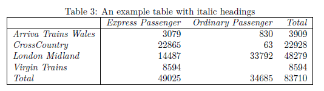

Latex Output

See the Latex Output vignette for more details.

### Styling

[interactive chart not shown]

See the Styling vignette for more details.

### Finding and Formatting Data Groups

[interactive chart not shown]

See the Finding and Formatting vignette for more details.

### Finding and Formatting Cells

[interactive chart not shown]

See the Finding and Formatting vignette for more details.

### Conditional Formatting

[interactive chart not shown]

See the Finding and Formatting vignette for more details.

### Irregular Layout

[interactive chart not shown]

See the Irregular Layout vignette for more details.

## Further Reading

The full set of vignettes is:

1. Introduction
2. Data Groups
3. Calculations
4. Outputs
5. Latex Output
6. Styling
7. Finding and Formatting
8. Cell Context
9. Irregular Layout
10. Performance
11. Shiny
12. Excel Export
13. Appendix: Details
14. Appendix: Calculations
15. Appendix: Class Overview
[^1]: The terms “fixed variables” and “measured variables” are used here as in [Wickham 2014](http://vita.had.co.nz/papers/tidy-data.html)
[^2]: This is the identifier assigned by the [Recent Train Times](http://www.recenttraintimes.co.uk) website, the source of this sample data
[^3]: pivottabler is implemented in [R6 Classes](https://CRAN.R-project.org/package=R6) so pt here is an instance of the R6 PivotTable class.